# Generalized Linear Model

###1. 일반화선형모델(Generalized Linear Models) 이란 ? # 선형모델(Linear Models)의 틀에 명백히, 비정규성을 따르는 종속변수를 포함하는 확장모델 - 조건적 평균 반응함수를 적합화 - 반응변수가 지수분포(exponential distribution)를 따른다 가정 - 표준선형모델을 확장 - 모수추정 : 최소제곱법(OLS)보다, 최대우도법(MLE)을 사용

###2. 일반화선형모델의 대표적인 두가지 모델 # 1. 로지스틱(Logistic) 회귀분석 : 결과변수가 범주형 변수(categorical variables) 인 경우 a) 이산형 변수 (예: 예/아니오, 성공/실패, 사망/생존 등) b) 다항 변수 (예: 미흡/좋음/매우좋음, 민주당/공화당/자유당 등)

```
2. 포아송(Poisson) 회귀분석 : 결과변수가 빈도(개수) 변수(count variables) 인 경우
  a) 변수의 값에 제한
  b) 음수가 없음
  c) 예: 항간질제의 8주 복용이 발작빈도에 미치는 영향분석
```

###3. 표준선형모델의 구조방정식
$$\mu_Y = \beta_0 + \sum\limits_{j=1}^{p}{\beta_{j}}{X_{j}}$$

```
표준선형모형 : Y와 X가 선형관계인 모형
  1) 종속변수 Y 가 정규성을 따른다(정규분포)고 가정
  2) 계수도출절차: 최소제곱합(OLS, Ordinary Least Squares)
```

###4. 일반화선형모델의 구조방정식
$$g(\mu_Y) = \beta_0 + \sum\limits_{j=1}^{p}{\beta_{j}}{X_{j}}$$

```
일반화선형모형 : Y와 X가 선형관계가 아닌 모형
```

- $g(\mu_Y)$ : 조건부 평균함수 == 연계함수(link function)
- Y 의 정규성 가정을 느슨하게 함. 대신 지수분포를 따른다고 가정
- 계수 도출 절차 :
  1. 연계함수(link function, $g(\mu_Y)$)와 확률분포를 특정하고,
  2. 반복적인 최대우도법(Maximum Likelyhood Estimation, MLE) 절차를 통해,  
     계수를 도출

###5. 최대우도법 (MLE, Maximum Likelyhood Estimation) # 관측치가 고정되고, 이 관측치가 나오게 하는, 가장 그럴듯한 모수값 추정 즉, 우도(likelyhood)를 가장 높아지게 하여, 모수를 추정하는 방법

```
※ 우도(=가능도, likelyhood) : 관측치가 관찰될 가능성(함수로 표현)
```

###6. glm{stats} 함수

```
1. Usage: glm( formula, family = family(link = function), data = )
2. family 인자
    - 특정 확률분포 지정
    - 지정한 확률분포에 상응하는 연계함수(link function) 지정
      ------------------------------------------------------------------------
             Family                       Default Link Function
       (특정 확률분포 지정)       (지정 확률분포에 상응하는 기본 연계함수, 생략가능)
      ------------------------------------------------------------------------
        binomial                  (link = 'logit')
        gaussian                  (link = 'identify')
        gamma                     (link = 'inverse')
        inverse.gaussian          (link = '1/m^2')
        poisson                   (link = 'log')
        quasi                     (link = 'identity', variance = 'constant')
        quasibinomial             (link = 'logit')
        quasipoisson              (link = 'log')
      ------------------------------------------------------------------------
3. 적합한 분석모형 :
    a. 로지스틱 회귀분석 (Logistic Regression)
    b. 포아송 회귀분석 (Poisson Regression)
    c. 생존분석 (Survival Analysis)
```

###7. 로지스틱 회귀분석 (logistic regression analysis)
$$log_e(\frac{\pi}{1-\pi}) = \beta_0 + \sum\limits_{j=1}^{p}{\beta_{j}}{X_{j}}$$

where,  
- $\pi = \mu_Y$ : Y 의 조건적 평균 (즉, 주어진 X 값들의 집합에서, Y = 1 인 확률)  
- $(\pi/1-\pi)$ : Y = 1 의 승산  
- $log(\pi/1-\pi)$ : 로그승산 또는 로짓(logit)  
- 지정 확률분포 : 이항분포를 따름  
- 지정 확률분포에 상응하는 연계함수 : $log_e(\frac{\pi}{1-\pi})$ (logit, 로그승산)  
- 적합화(fitting) :

```
  > glm(Y ~ X1 + X2 + X3, family = binominal(link = 'logit'), data = mydata)
```

###8. 포아송 회귀분석 (poisson regression analysis)
$$log_e(\lambda) = \beta_0 + \sum\limits_{j=1}^{p}{\beta_{j}}{X_{j}}$$

where,  
- $\lambda$ : Y의 평균  
- 지정 확률분포 : 포아송 분포를 따름  
- 지정 확률분포에 상응하는 연계함수 : $log(\lambda)$  
- 적합화(fitting) :

```
  > glm(Y ~ X1 + X2 + X3, family = poisson(link = 'log'), data = mydata)
```

###9. 표준선형모델은, 일반화선형모델의 특별한 사례임
$$\mu_Y = \beta_0 + \sum\limits_{j=1}^{p}{\beta_{j}}{X_{j}}$$

where,  
- 지정 확률분포 : 정규분포(gaussian)를 따름  
- 지정 확률분포에 상응하는 연계함수 : $g(\mu_Y) = \mu_Y$ or ‘identity’ - 적합화(fitting) :

```
  > glm(Y ~ X1 + X2 + X3, family = gaussian(link = 'identity'), data = mydata)
  > lm(Y ~ X1 + X2 + X3, data = mydata)
```

###10. 일반화선형모델의 지원함수들

```
표준선형모델의 지원함수들에 상응하는 버전을 제공
-------------------------------------------------------------------------------
      Supported functions                       Descriptions
-------------------------------------------------------------------------------
  summary()                       Fitted Model의 세부결과 출력
  coefficients(), coef()          Fitted Model의 모델모수목록(절편,기울기) 제공
  confint()                       모델모수의 신뢰구간 제공(기본: 95%)
  residuals()                     Fitted Model의 잔차목록 제공
  anova()                         2개의 Fitted Model을 비교, ANOVA 표 생성
  plot()                          Fitted Model의 적합성 평가위한 진단플롯 생성
  predict()                       Fitted Model을 통해, 새로운 데이터셋의 반응값 예측
  deviance()                      Fitted Model의 편차 반환
  df.residual()                   Fitted Model의 잔차 자유도 반환
-------------------------------------------------------------------------------
```

###11. 일반화선형모델의 적합성 진단(diagnostics)

```
1) 모델 적합성 평가는, OLS 회귀분석과 마찬가지로 일반화 회귀분석에서도 중요함
2) 그러나 적절한 평가절차에 대한 통계공동체의 합의가 거의 없음
3) 모델 적합성 평가를 위한 전형적 방법
    - 원래 반응변수의 행렬에 표현된 예측변수를,
      이탈유형의 잔차에 대응하여 플롯 생성
    - 일반적인 진단플롯은 아래와 같음
        아래의 코드를 통해, R이 제공하는,
          가. 모수치 (hat values)
          나. 스튜던트 잔차 (studentized residuals)
          다. 쿡의 거리 (Cook's Distance)

        > plot( predict( model, type = 'response' ) )
        > residuals( model, type = 'deviance' )

        ※ model : glm{stats} 함수가 반환한 객체
4) 특이한(문제가 있는) 관측치(이상치, 영향치, 지렛대 등)를 확인하기 위한,
   cutoff 변수를 정하는데, 일반적으로 합의된 방법은 없음
   - 다른 변수와 비교해서, 상대적으로 평가해야 함
   - 하나의 접근법으로는, 각 통계치에 대한 인덱스 플롯을 생성하고
     예외적인 값을 조사

     예를들어, 3가지 진단플롯 산출을 위해, 아래 코드 사용 가능

     > plot( hatvalues(model) )
     > plot( rstudent(model) )
     > plot( cooks.distance(model) )

   - 다른 접근법으로, 아래 코드를 이용해, 하나의 omnibus 플롯 산출가능

     > library(car)
     > influencePlot(model)

     ※ 수평축: 지렛대(leverage),
        수직축: 표준화 잔차,
        플롯기호: 쿡의 거리에 비례
5) 4)의 진단플롯은,
  - 결과변수가 많은 수치를 가지고 있을 때는, 크게 도움이 되나,
  - 결과변수의 수치가 제한적인 경우(예: 로지스틱회귀분석), 플롯의 유용성 감소
```

###12. 로지스틱 회귀분석 (logistic regression analysis)

```
일련의 연속적 및 혹은 범주화된 예측변수의 집합으로부터 이분법적인 결과를 예측하고자 할 때, 유용함
```

```r
# install.packages('AER', dependencies = TRUE)
library(AER)
data(Affairs)

summary(Affairs)
```

```
##     affairs          gender         age         yearsmarried    children
##  Min.   : 0.000   female:315   Min.   :17.50   Min.   : 0.125   no :171
##  1st Qu.: 0.000   male  :286   1st Qu.:27.00   1st Qu.: 4.000   yes:430
##  Median : 0.000                Median :32.00   Median : 7.000
##  Mean   : 1.456                Mean   :32.49   Mean   : 8.178
##  3rd Qu.: 0.000                3rd Qu.:37.00   3rd Qu.:15.000
##  Max.   :12.000                Max.   :57.00   Max.   :15.000
##  religiousness     education       occupation        rating
##  Min.   :1.000   Min.   : 9.00   Min.   :1.000   Min.   :1.000
##  1st Qu.:2.000   1st Qu.:14.00   1st Qu.:3.000   1st Qu.:3.000
##  Median :3.000   Median :16.00   Median :5.000   Median :4.000
##  Mean   :3.116   Mean   :16.17   Mean   :4.195   Mean   :3.932
##  3rd Qu.:4.000   3rd Qu.:18.00   3rd Qu.:6.000   3rd Qu.:5.000
##  Max.   :5.000   Max.   :20.00   Max.   :7.000   Max.   :5.000
```

```r
library(prettyR)
freq(Affairs$affairs)
```

```
##
## Frequencies for Affairs$affairs
##         0    7   12    1    3    2   NA
##       451   42   38   34   19   17    0
## %      75    7  6.3  5.7  3.2  2.8    0
## %!NA   75    7  6.3  5.7  3.2  2.8
```

```r
library(DT)
datatable(Affairs)
```

|  | affairs | gender | age | yearsmarried | children | religiousness | education | occupation | rating |
| --- | --- | --- | --- | --- | --- | --- | --- | --- | --- |
| 4 | 0 | male | 37 | 10 | no | 3 | 18 | 7 | 4 |
| 5 | 0 | female | 27 | 4 | no | 4 | 14 | 6 | 4 |
| 11 | 0 | female | 32 | 15 | yes | 1 | 12 | 1 | 4 |
| 16 | 0 | male | 57 | 15 | yes | 5 | 18 | 6 | 5 |
| 23 | 0 | male | 22 | 0.75 | no | 2 | 17 | 6 | 3 |
| 29 | 0 | female | 32 | 1.5 | no | 2 | 17 | 5 | 5 |
| 44 | 0 | female | 22 | 0.75 | no | 2 | 12 | 1 | 3 |
| 45 | 0 | male | 57 | 15 | yes | 2 | 14 | 4 | 4 |
| 47 | 0 | female | 32 | 15 | yes | 4 | 16 | 1 | 2 |
| 49 | 0 | male | 22 | 1.5 | no | 4 | 14 | 4 | 5 |

[output cut: 591 more lines]

```
만남횟수(Affairs$affairs) 변수가 있지만, 현 분석의 목표은, 불륜경험여부라는 이분법적인 결과임.
분석목표에 맞는 파생변수(Affairs$ynAffair, factor타입)를 생성함
```

```r
Affairs$ynAffair[Affairs$affairs > 0] <- 1
Affairs$ynAffair[Affairs$affairs == 0] <- 0

Affairs$ynAffair <- factor(Affairs$ynAffair, levels = c(0, 1), labels = c('No', 'Yes'))
```

```r
library(prettyR)
freq(Affairs$ynAffair)
```

```
##
## Frequencies for Affairs$ynAffair
##        No  Yes   NA
##       451  150    0
## %      75   25    0
## %!NA   75   25
```

```
불륜여부라는 결과(반응,종속)변수에 대한, 로지스틱 회귀분석을 적합시킴(fitting)
```

```r
fit.full <- glm(ynAffair ~ gender + age + yearsmarried + children + religiousness + education + occupation + rating, data = Affairs, family = binomial(link = 'logit'))

# The same formula, family and link function
# fit.full <- glm(ynAffair ~ . - affairs, data = Affairs, family = binomial())

# The same formula, family and link function
# fit.full <- glm(ynAffair ~ . - affairs, data = Affairs, family = binomial)

fit.full
```

```
##
## Call:  glm(formula = ynAffair ~ gender + age + yearsmarried + children +
##     religiousness + education + occupation + rating, family = binomial(link = "logit"),
##     data = Affairs)
##
## Coefficients:
##   (Intercept)     gendermale            age   yearsmarried    childrenyes
##       1.37726        0.28029       -0.04426        0.09477        0.39767
## religiousness      education     occupation         rating
##      -0.32472        0.02105        0.03092       -0.46845
##
## Degrees of Freedom: 600 Total (i.e. Null);  592 Residual
## Null Deviance:       675.4
## Residual Deviance: 609.5     AIC: 627.5
```

```
각 회귀계수의 유의확률(P-value)에 대한, 가설설정은 아래와 같음
  H0 : 모회귀계수는 0임
  H1 : not H0
```

```r
summary(fit.full)
```

```
##
## Call:
## glm(formula = ynAffair ~ gender + age + yearsmarried + children +
##     religiousness + education + occupation + rating, family = binomial(link = "logit"),
##     data = Affairs)
##
## Deviance Residuals:
##     Min       1Q   Median       3Q      Max
## -1.5713  -0.7499  -0.5690  -0.2539   2.5191
##
## Coefficients:
##               Estimate Std. Error z value Pr(>|z|)
## (Intercept)    1.37726    0.88776   1.551 0.120807
## gendermale     0.28029    0.23909   1.172 0.241083
## age           -0.04426    0.01825  -2.425 0.015301 *
## yearsmarried   0.09477    0.03221   2.942 0.003262 **
## childrenyes    0.39767    0.29151   1.364 0.172508
## religiousness -0.32472    0.08975  -3.618 0.000297 ***
## education      0.02105    0.05051   0.417 0.676851
## occupation     0.03092    0.07178   0.431 0.666630
## rating        -0.46845    0.09091  -5.153 2.56e-07 ***
## ---
## Signif. codes:  0 '***' 0.001 '**' 0.01 '*' 0.05 '.' 0.1 ' ' 1
##
## (Dispersion parameter for binomial family taken to be 1)
##
##     Null deviance: 675.38  on 600  degrees of freedom
## Residual deviance: 609.51  on 592  degrees of freedom
## AIC: 627.51
##
## Number of Fisher Scoring iterations: 4
```

```r
fit.reduced <- glm(ynAffair ~ age + yearsmarried + religiousness + rating, data = Affairs, family = binomial(link = 'logit'))

# The same formula, family and link function
# fit.reduced <- glm(ynAffair ~ . - affairs - gender - children - education - occupation, data = Affairs, family = binomial())

# The same formula, family and link function
# fit.reduced <- glm(ynAffair ~ . - affairs - gender - children - education - occupation, data = Affairs, family = binomial)

fit.reduced
```

```
##
## Call:  glm(formula = ynAffair ~ age + yearsmarried + religiousness +
##     rating, family = binomial(link = "logit"), data = Affairs)
##
## Coefficients:
##   (Intercept)            age   yearsmarried  religiousness         rating
##       1.93083       -0.03527        0.10062       -0.32902       -0.46136
##
## Degrees of Freedom: 600 Total (i.e. Null);  596 Residual
## Null Deviance:       675.4
## Residual Deviance: 615.4     AIC: 625.4
```

```
각 회귀계수의 유의확률(P-value)에 대한, 가설설정은 아래와 같음
  H0 : 모회귀계수는 0임
  H1 : not H0
```

```r
summary(fit.reduced)
```

```
##
## Call:
## glm(formula = ynAffair ~ age + yearsmarried + religiousness +
##     rating, family = binomial(link = "logit"), data = Affairs)
##
## Deviance Residuals:
##     Min       1Q   Median       3Q      Max
## -1.6278  -0.7550  -0.5701  -0.2624   2.3998
##
## Coefficients:
##               Estimate Std. Error z value Pr(>|z|)
## (Intercept)    1.93083    0.61032   3.164 0.001558 **
## age           -0.03527    0.01736  -2.032 0.042127 *
## yearsmarried   0.10062    0.02921   3.445 0.000571 ***
## religiousness -0.32902    0.08945  -3.678 0.000235 ***
## rating        -0.46136    0.08884  -5.193 2.06e-07 ***
## ---
## Signif. codes:  0 '***' 0.001 '**' 0.01 '*' 0.05 '.' 0.1 ' ' 1
##
## (Dispersion parameter for binomial family taken to be 1)
##
##     Null deviance: 675.38  on 600  degrees of freedom
## Residual deviance: 615.36  on 596  degrees of freedom
## AIC: 625.36
##
## Number of Fisher Scoring iterations: 4
```

[output not shown]

```r
anova(fit.reduced, fit.full, test = 'Chisq')
```

```
## Analysis of Deviance Table
##
## Model 1: ynAffair ~ age + yearsmarried + religiousness + rating
## Model 2: ynAffair ~ gender + age + yearsmarried + children + religiousness +
##     education + occupation + rating
##   Resid. Df Resid. Dev Df Deviance Pr(>Chi)
## 1       596     615.36
## 2       592     609.51  4   5.8474   0.2108
```

```
● 모델 모수(즉, 모회귀계수)의 해석
  - 로지스틱 회귀분석에서, 모델화된 반응은, Y=1일 때의 로그(승산)임
  - 회귀계수는 모든 다른 예측변수가 일정할 때(통제), 한
    예측변수의 단위 당 변화에 대한, 반응변수의 로그(승산)의 변화를 의미함.
```

```r
coef(fit.reduced)
```

```
##   (Intercept)           age  yearsmarried religiousness        rating
##    1.93083017   -0.03527112    0.10062274   -0.32902386   -0.46136144
```

```
그러나 로그(승산, Logarithms)는 해석하기 어렵기 때문에, 결과를 승산척도로 지수화(상대적인 비율, Exponentials) 할 수 있음
```

```r
exp( coef(fit.reduced) )
```

```
##   (Intercept)           age  yearsmarried religiousness        rating
##     6.8952321     0.9653437     1.1058594     0.7196258     0.6304248
```

```
따라서 위의 지수로 해석하면,
  - 결혼기간(yearsmarried)이 1년 증가할 때함
    (단, 다른 예측변수들은 일정할 때, 즉 통제하에 있을 때),
    혼외정사의 승산이 1.106배 증가
  - 역으로, 연령(age)이 1년 증가하면서 혼회정사의 승산이 0.965배 변화함
  - 즉 혼외정사의 승산은, 결혼기간의 증가에 따라서 증가하는 반면,
    연령/종교/결혼만족도의 증가에 따라 감소함을 알 수 있
  - 또한 이 모형에서 모든 예측변수가 0이 될 수 없으므로,
    절편(intercept)은 의미가 없음
```

```
모형의 각 회귀계수에 대한 신뢰구간(confidence interval)을 구하려면,
  > exp( confint(fit.reduced) )
  위의 코드를 통해, 승산척도인 각 계수의 95% 신뢰구간을 산출
```

```r
exp( confint(fit.reduced) )
```

```
##                   2.5 %     97.5 %
## (Intercept)   2.1255764 23.3506030
## age           0.9323342  0.9981470
## yearsmarried  1.0448584  1.1718250
## religiousness 0.6026782  0.8562807
## rating        0.5286586  0.7493370
```

```
만일 예측변수의 일(한) 단위 변화에 대한 관심보다,
이항 로지스틱 회귀분석에서,
  - 반응변수에서 높은 변수값의 승산변화에 따른,
  - 예측변수 n단위 변화는 exp(β)^n 이 됨
따라서 위의 축소모형의 회귀계수에 따르면, 느느
  - 결혼기간(yearsmarried)의 1년 증가는
  - 다른 예측변수가 일정할 때, 불륜승산이 1.1106배 커지며,
  - 결혼기간의 10년 증가시, 불륜승산이 1.106^10 (약 2.7)배 승산증가 할 것임
```

```
● 결과확률에 대한 예측변수의 효과평가
  - 승산(로그)보다는, 확률을 이해하고 해석하기 쉬움
  - 결과확률에 대한, 예측변수의 효과를 관찰하기 위해 predict{stats} 함수 사용
  - predict{stats} 함수의 사용절차
    1. 관심이 있는 예측변수 값이 포함된, 인위적인 데이터셋을 만듦
    2. 이 인위적인 예측변수의 값에 따라, 결과가 발생하는 확률을 예측
```

```r
# 1. 관심이 있는 예측변수 값이 포함된, 인위적인 데이터셋을 만듦
testdata <- data.frame(
  rating = c(1,2,3,4,5),
  age = mean(Affairs$age),
  yearsmarried = mean(Affairs$yearsmarried),
  religiousness = mean(Affairs$religiousness)
)

library(DT)
datatable(testdata)
```

|  | rating | age | yearsmarried | religiousness |
| --- | --- | --- | --- | --- |
| 1 | 1 | 32.4875207986689 | 8.17769550748752 | 3.11647254575707 |
| 2 | 2 | 32.4875207986689 | 8.17769550748752 | 3.11647254575707 |
| 3 | 3 | 32.4875207986689 | 8.17769550748752 | 3.11647254575707 |
| 4 | 4 | 32.4875207986689 | 8.17769550748752 | 3.11647254575707 |
| 5 | 5 | 32.4875207986689 | 8.17769550748752 | 3.11647254575707 |

```r
# 2. 이 인위적인 예측변수의 값에 따라, 결과가 발생하는 확률을 예측
suppressWarnings(expr = {
  testdata$prob <- predict(fit.reduced, newdata = testdata, type = 'response')
})

testdata
```

```
##   rating      age yearsmarried religiousness      prob
## 1      1 32.48752     8.177696      3.116473 0.5302296
## 2      2 32.48752     8.177696      3.116473 0.4157377
## 3      3 32.48752     8.177696      3.116473 0.3096712
## 4      4 32.48752     8.177696      3.116473 0.2204547
## 5      5 32.48752     8.177696      3.116473 0.1513079
```

```
위의 결과에서 혼회정사 확률(prob)이,
  - 결혼만족(rating)이 1(매우 불행)일 때, 0.53 (prob)에서,
  - 결혼만족(rating)이 5(매우 만족)일 때, 0.15 (prob)로 감소
함을 알 수 있음.
(단, 결혼만족을 제외한 기타 예측변수들을 모두 통제할 때)
```

```r
# 1. 관심이 있는 예측변수 값이 포함된, 인위적인 데이터셋을 만듦
testdata <- data.frame(
  rating = mean(Affairs$rating),
  age = seq(17, 57, by = 10),
  yearsmarried = mean(Affairs$yearsmarried),
  religiousness = mean(Affairs$religiousness)
)

library(DT)
datatable(testdata)
```

|  | rating | age | yearsmarried | religiousness |
| --- | --- | --- | --- | --- |
| 1 | 3.93178036605657 | 17 | 8.17769550748752 | 3.11647254575707 |
| 2 | 3.93178036605657 | 27 | 8.17769550748752 | 3.11647254575707 |
| 3 | 3.93178036605657 | 37 | 8.17769550748752 | 3.11647254575707 |
| 4 | 3.93178036605657 | 47 | 8.17769550748752 | 3.11647254575707 |
| 5 | 3.93178036605657 | 57 | 8.17769550748752 | 3.11647254575707 |

```r
# 2. 이 인위적인 예측변수의 값에 따라, 결과가 발생하는 확률을 예측
suppressWarnings(expr = {
  testdata$prob <- predict(fit.reduced, newdata = testdata, type = 'response')
})

testdata
```

```
##    rating age yearsmarried religiousness      prob
## 1 3.93178  17     8.177696      3.116473 0.3350834
## 2 3.93178  27     8.177696      3.116473 0.2615373
## 3 3.93178  37     8.177696      3.116473 0.1992953
## 4 3.93178  47     8.177696      3.116473 0.1488796
## 5 3.93178  57     8.177696      3.116473 0.1094738
```

```
위의 결과에서 혼외정사 확률이,
  - 연령(age)이 17 -> 57로 증가할 때,
    혼외정사 확률은 0.34 -> 0.11로 감소함

※ 위와 같은 방법으로, 각 예측변수가 결과에 미치는 효과를 탐색할 수 있음
```

● 과대산포(Overdispersion)  
- 이항분포로부터 추출한 데이터에서, 예상되는 분산은 $\sigma^{2} = n\pi(1-\pi)$ 임 - where,  
n : 관찰 사례수  
$\pi$ : Y=1 인 집단에 속하는 확률  
- 결과변수의 관찰된 분산이, 이항분포에서 기대되는 분산에 비해 클 때 발생  
- 왜곡된 표준오차와 부정확한 유의도 검정에 이르게 함  
- 과대산포가 존재할 때 glm{stats} 함수를 통해, 로지스틱 회귀모형으로 적합화 할 수 있음  
a. 이때 이항분포(binomial)보다는 준이항(quasibinomial)분포를 이용해야 함  
b. 과대산포를 점검하는 하나의 방법은, 이항모형에 있는 잔차 자유도를 전차편차와 비교하는 것임  
(이때, 비율이 1보다 **현저하게** 크다면, 과대산포의 증거임)

$$Φ = \frac{잔차편차(Residual deviance)}{잔차자유도(Residual df)}$$

```r
overdispersion_ratio = deviance(fit.reduced) / df.residual(fit.reduced)
overdispersion_ratio
```

```
## [1] 1.03248
```

```
위의 비율이 1에 가깝기 때문에, 과대산포(Overdispersion)은 없음
```

● 과대산포(Overdispersion)의 유의성 검정

```
- 우선 모형을 두 번 적합화 해야 함

   a. 첫 번째는, `family = 'binomial'` 로 적합화
```

```r
( fit <- glm(ynAffair ~ age + yearsmarried + religiousness + rating, family = binomial, data = Affairs) )
```

```
##
## Call:  glm(formula = ynAffair ~ age + yearsmarried + religiousness +
##     rating, family = binomial, data = Affairs)
##
## Coefficients:
##   (Intercept)            age   yearsmarried  religiousness         rating
##       1.93083       -0.03527        0.10062       -0.32902       -0.46136
##
## Degrees of Freedom: 600 Total (i.e. Null);  596 Residual
## Null Deviance:       675.4
## Residual Deviance: 615.4     AIC: 625.4
```

```
   b. 두 번째는, `family = 'quasibinomial'` 로 적합화 (과대산포가 존재시, 적합화 시에 지정)
```

```r
( fit.od <- glm(ynAffair ~ age + yearsmarried + religiousness + rating, family = quasibinomial, data = Affairs) )
```

```
##
## Call:  glm(formula = ynAffair ~ age + yearsmarried + religiousness +
##     rating, family = quasibinomial, data = Affairs)
##
## Coefficients:
##   (Intercept)            age   yearsmarried  religiousness         rating
##       1.93083       -0.03527        0.10062       -0.32902       -0.46136
##
## Degrees of Freedom: 600 Total (i.e. Null);  596 Residual
## Null Deviance:       675.4
## Residual Deviance: 615.4     AIC: NA
```

```
 - 다음으로 아래와 같이 가설설정
      - H0 : Φ = 1    (과대산포가 없다)
      - H1 : Φ != 1   (과대산포가 있다)
```

```
 - 마지막으로 pchisq{stats} 함수를 이용하여, 과대산포에 대한 가설검정 수행
```

```r
p_value <- pchisq(
  summary(fit.od)$dispersion * fit$df.residual,
  fit$df.residual,
  lower = FALSE
)

cat('p-value of overdispersion: ', p_value)
```

```
## p-value of overdispersion:  0.340122
```

```
  - p값이 통계적으로 유의미하지 않으므로, 귀무가설 채택 (H0 : Φ = 1)
  - 즉 과대산포에 문제가 없음을 강력히 지지함
```

###13. 로지스틱 회귀분석의 확장 및 변이

```
(1) 로버스트 로지스틱 회귀분석(Robust logistic regression)
    - glmRob{robust} 함수를 이용하여 모델 적합화 수행
    - 이상치와 영향치를 포함하는 로지스틱 회귀모델를 적합화 하는데 이용
    - 로버스트 일반화선형모델의 적합화를 위해 수행
(2) 다항 로지스틱 회귀분석(Multinomial logistic regression)
    - 반응변수가 세 개 이상의 비서열적 범주(예: 미혼/기혼/이혼)를 가진 경우
    - mlogit{mlogit} 함수를 이용하여 모델 적합화 수행
(3) 서열적 로지스틱 회귀분석(Ordinal logistic regression)
    - 반응변수가 서열변수일 때(예: 나쁨/좋음/우수 같은 신용위험도)
    - lrm{rms} 함수를 이용하여 모델 적합화 수행
(4) 다중범주 로지스틱 회귀분석
    - 다중범주(순서가 있는 범주와 순서가 없는 범주 모두)를 가진 반응변수를 모델화 하는 능력은 중요한 확장임
    - 그러나 여기엔 해석의 복잡성이 존재하게 됨
    - 이 경우, 모델 적합성과 회귀진단에 대한 평가 역시 보다 복잡함
```

###14. 포아송 회귀분석(Poisson regression)

```
연속적이거나 범주화된 예측변수의 집합으로부터 나온, 결과변수가 빈도변수(count variables) 일 때,
이를(빈도) 예측하고자 할 때 유용함
```

```r
library(robust)
data(breslow.dat)
```

```
자료는, {robust} 패키지에서 제공하는, Breslow의 발작 자료임
특히 항경련제의 8주 복용이, 발작빈도에 미치는 영향을 검토함
  - 연령과 발작빈도임
  - 발작빈도는 8주 전과 후의 단순 혹은 복합부분 발작의 수
  - 실험대상은 위약(placebo)과 항경련제(progabide) 투여집단으로, 무작위 할당
  - SumY (무작위 이후, 8주동안의 발작빈도)가 반응변수임
  - 치료조건(Trt), 연령(Age), 8주간보고된 발작빈도(Base)가 예측변수임
  - 기초발작빈도(base)와 연령은, 이들이 반응변수에 미치는 잠재적 효과 때문에 포함됨
```

```
※ 분석목표: 공변수들을 고려한 후에, 약물투여가 발작빈도를 감소시키는 증거가 있는지 확인
```

```r
library(DT)
datatable(breslow.dat)
```

|  | ID | Y1 | Y2 | Y3 | Y4 | Base | Age | Trt | Ysum | sumY | Age10 | Base4 |
| --- | --- | --- | --- | --- | --- | --- | --- | --- | --- | --- | --- | --- |
| 1 | 104 | 5 | 3 | 3 | 3 | 11 | 31 | placebo | 14 | 14 | 3.1 | 2.75 |
| 2 | 106 | 3 | 5 | 3 | 3 | 11 | 30 | placebo | 14 | 14 | 3 | 2.75 |
| 3 | 107 | 2 | 4 | 0 | 5 | 6 | 25 | placebo | 11 | 11 | 2.5 | 1.5 |
| 4 | 114 | 4 | 4 | 1 | 4 | 8 | 36 | placebo | 13 | 13 | 3.6 | 2 |
| 5 | 116 | 7 | 18 | 9 | 21 | 66 | 22 | placebo | 55 | 55 | 2.2 | 16.5 |
| 6 | 118 | 5 | 2 | 8 | 7 | 27 | 29 | placebo | 22 | 22 | 2.9 | 6.75 |
| 7 | 123 | 6 | 4 | 0 | 2 | 12 | 31 | placebo | 12 | 12 | 3.1 | 3 |
| 8 | 126 | 40 | 20 | 23 | 12 | 52 | 42 | placebo | 95 | 95 | 4.2 | 13 |
| 9 | 130 | 5 | 6 | 6 | 5 | 23 | 37 | placebo | 22 | 22 | 3.7 | 5.75 |
| 10 | 135 | 14 | 13 | 6 | 0 | 10 | 28 | placebo | 33 | 33 | 2.8 | 2.5 |

[output cut: 49 more lines]

```r
names(breslow.dat)
```

```
##  [1] "ID"    "Y1"    "Y2"    "Y3"    "Y4"    "Base"  "Age"   "Trt"   "Ysum"
## [10] "sumY"  "Age10" "Base4"
```

```r
summary(breslow.dat[c(6,7,8,10)])
```

```
##       Base             Age               Trt          sumY
##  Min.   :  6.00   Min.   :18.00   placebo  :28   Min.   :  0.00
##  1st Qu.: 12.00   1st Qu.:23.00   progabide:31   1st Qu.: 11.50
##  Median : 22.00   Median :28.00                  Median : 16.00
##  Mean   : 31.22   Mean   :28.34                  Mean   : 33.05
##  3rd Qu.: 41.00   3rd Qu.:32.00                  3rd Qu.: 36.00
##  Max.   :151.00   Max.   :42.00                  Max.   :302.00
```

```
위의 요약통계결과,
  - 기초발작빈도(base)와 무작위화 이후 발작의 분포(sumY)는 크게 치우쳐 있음
```

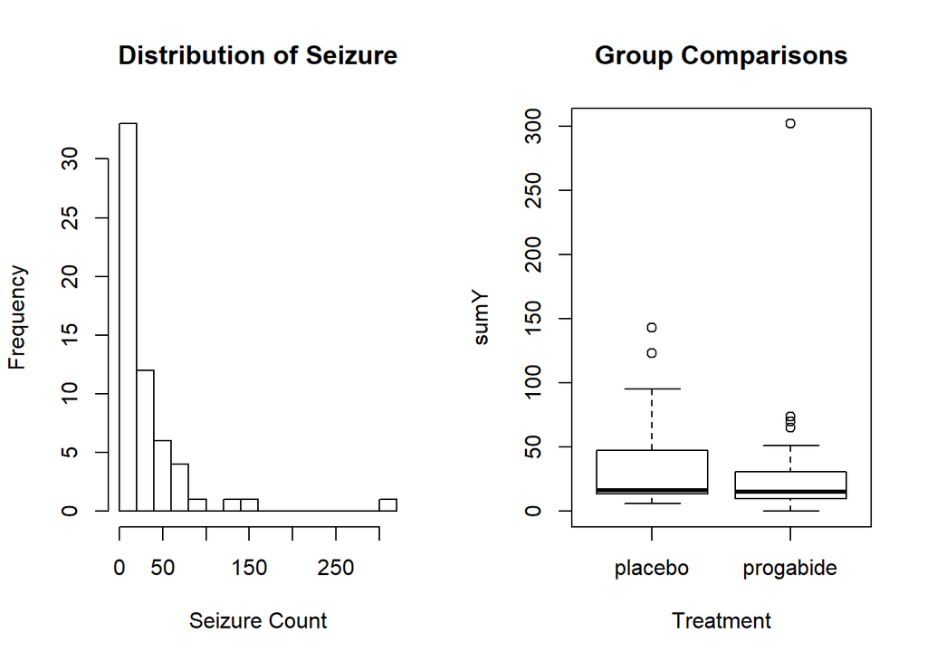

```r
op <- par(no.readonly = TRUE)
par(mfrow=c(1,2))

attach(breslow.dat)

hist(sumY, breaks = 20, xlab = 'Seizure Count', main = 'Distribution of Seizure')
boxplot(sumY ~ Trt, xlab = 'Treatment', main = 'Group Comparisons')
```

```r
par(op)
```

```
위의 플롯에서,
  - 종속변수가 치우쳐 있으며
  - 이상치의 존재를 분명히 알 수 있음
  - 약물복용중 발작 빈도는 더 적어지고, 분산도 적음
    (포아송 분포에서는, 평균이 작을수록, 분산이 더 작아질 것을 기대가능)
```

```
포아송 회귀분석에서는, 이분산성(등분산성의 반대)은 문제가 되지 않음
```

```r
( fit <- glm(sumY ~ Base + Age + Trt, data = breslow.dat, family = poisson) )
```

```
##
## Call:  glm(formula = sumY ~ Base + Age + Trt, family = poisson, data = breslow.dat)
##
## Coefficients:
##  (Intercept)          Base           Age  Trtprogabide
##      1.94883       0.02265       0.02274      -0.15270
##
## Degrees of Freedom: 58 Total (i.e. Null);  55 Residual
## Null Deviance:       2123
## Residual Deviance: 559.4     AIC: 850.7
```

```r
summary(fit)
```

```
##
## Call:
## glm(formula = sumY ~ Base + Age + Trt, family = poisson, data = breslow.dat)
##
## Deviance Residuals:
##     Min       1Q   Median       3Q      Max
## -6.0569  -2.0433  -0.9397   0.7929  11.0061
##
## Coefficients:
##                Estimate Std. Error z value Pr(>|z|)
## (Intercept)   1.9488259  0.1356191  14.370  < 2e-16 ***
## Base          0.0226517  0.0005093  44.476  < 2e-16 ***
## Age           0.0227401  0.0040240   5.651 1.59e-08 ***
## Trtprogabide -0.1527009  0.0478051  -3.194   0.0014 **
## ---
## Signif. codes:  0 '***' 0.001 '**' 0.01 '*' 0.05 '.' 0.1 ' ' 1
##
## (Dispersion parameter for poisson family taken to be 1)
##
##     Null deviance: 2122.73  on 58  degrees of freedom
## Residual deviance:  559.44  on 55  degrees of freedom
## AIC: 850.71
##
## Number of Fisher Scoring iterations: 5
```

```
위의 회귀모형 요역결과에서,
  - 편차, 모회귀계수, 표준오차 그리고 귀무가설(H0: 모회귀계수가 0임)의 검정결과를 제공함
  - 모든 예측변수는 통계적으로 유의미함
```

```
● 모회귀계수의 해석
  - 모델계수는 coef{stats} 함수를 이용하거나, summary{stats} 함수의 결과물에 있는 Coefficients 테이블에서 얻음
```

```r
coef(fit)
```

```
##  (Intercept)         Base          Age Trtprogabide
##   1.94882593   0.02265174   0.02274013  -0.15270095
```

```
  - 포아송 회귀분석에서 종속변수는 조건평균의 로그(log(λ))임
  - 연령(age) 회귀계수는 연령이 한살 증가하면, 기초발작빈도(Base)와 치료조건(Trt)이 일정할 때,
    발작의 로그평균이 0.0227 증가함을 의미
  - 실험참여자 중, 기초발작빈도(Base)나 연령(Age)이 0인 사례가 없기 때문에,
    이 사례에서 절편은 의미가 없음
```

```r
exp(coef(fit))
```

```
##  (Intercept)         Base          Age Trtprogabide
##    7.0204403    1.0229102    1.0230007    0.8583864
```

[output not shown]

```
● 과대산포(Overdispersion)
  - 로지스틱 회귀분석과 마찬가지로, 포아송 회귀분석에서도 과대산포 문제를 평가해야 함
  - 포아송 분포에서, 분산과 평균은 같음
  - 포아송 분포에서 과대산포는, 반응변수의 관찰된 분산이 포아송 분포의 예측치보다 클 때에 발생
  - 과대산포는 빈도자료를 다룰 때 종종 출현하며, 결과해석에 부정적 영향을 미치기 때문에, 이에 대해 자세히 검토할 필요가 있음
  - 과대산포가 발생하는 이유는 여러가지임 :
    가. 중요한 예측변수의 누락
    나. 상태의존성(State dependency)현상
        + 관찰대상 내에서 빈도는, 각 사건(event)의 독립성을 가정함
        + 발작자료의 사례에서, 각 환자에게 발작이 발생할 확률은, 다른 발작으로부터 독립적이라고 가정함
        + 그러나 위의 가정은 종종 지지되기 어려움
        + 특정 개인의 발작이 발생할 확률은, 이미 39번째 발작이 일어난 상태에서, 40번째 발작을 할 확률과 동일하지 않을 가능성이 큼
    다. 시계열 연구에서, 자료의 반복측정에 내재한 집락화(Clustering)
  - 과대산포가 존재하지만, 모델에서 이를 고려하지 않는다면,
    가. 표준오차와 신뢰구간이 너무 적고
    나. 통계적 유의성 검정도 너무 관대해짐 (즉, 존재하지 않는 효과를 발견)
  - 로지스틱 회귀분석과 마찬가지로, 잔차의 자유도에 대한 잔차편차의 비율이 1보다 훨씬 크다면, 과대분산(overdispersion)을 시사함
```

```
{qcc} 패키지에서 포아송 사례의 과대분산 검정을 제공함
  - 아래에서, 유의도 검정결과 p-value가 유의수준(0.05)보다 작기 때문에, 과대산포를 강력히 시사함
    (H0 : 과대산포가 없음, H1 : 과대산포가 있음)
```

```r
library(qcc)
qcc.overdispersion.test(breslow.dat$sumY, type = 'poisson')
```

```
##
## Overdispersion test Obs.Var/Theor.Var Statistic p-value
##        poisson data          62.87013  3646.468       0
```

```
  - glm{stats} 함수를 이용하여, family='poisson'을, family='quasipoisson'으로
    대체하여 모델을 적합화 할 수 있음 (이는, 로지스틱 회귀분석에서 과대산포 존재시 적용했던 방법과 동일함)
  - 의사포아송 접근에서, 모수검정은 포아송 접근과 동일함
    그러나 표준오차가 매우 큼
  - 아래 예제와 같이, 표준오차가 커짐으로서, Trt와 Age이 통계적으로 유의미하지 않은 결과를 가져옴
  - 과대산포를 고려할 때, 기초발작빈도(Base)와 연령(Age)을 통제한 후 항경련제를 복용한다고 해서,
    위약복용보다 발작빈도를 감소시킨다고 선언할 근거는 충분하지 않음
  - 과대산포로 인한 아래의 결과는, 실제 현실에서 항경련제 효능에 대한 어떠한 함축도 포함하고 있지 않음
```

```r
( fit.od <- glm(sumY ~ Base + Age + Trt, data = breslow.dat, family = quasipoisson) )
```

```
##
## Call:  glm(formula = sumY ~ Base + Age + Trt, family = quasipoisson,
##     data = breslow.dat)
##
## Coefficients:
##  (Intercept)          Base           Age  Trtprogabide
##      1.94883       0.02265       0.02274      -0.15270
##
## Degrees of Freedom: 58 Total (i.e. Null);  55 Residual
## Null Deviance:       2123
## Residual Deviance: 559.4     AIC: NA
```

```r
summary(fit.od)
```

```
##
## Call:
## glm(formula = sumY ~ Base + Age + Trt, family = quasipoisson,
##     data = breslow.dat)
##
## Deviance Residuals:
##     Min       1Q   Median       3Q      Max
## -6.0569  -2.0433  -0.9397   0.7929  11.0061
##
## Coefficients:
##               Estimate Std. Error t value Pr(>|t|)
## (Intercept)   1.948826   0.465091   4.190 0.000102 ***
## Base          0.022652   0.001747  12.969  < 2e-16 ***
## Age           0.022740   0.013800   1.648 0.105085
## Trtprogabide -0.152701   0.163943  -0.931 0.355702
## ---
## Signif. codes:  0 '***' 0.001 '**' 0.01 '*' 0.05 '.' 0.1 ' ' 1
##
## (Dispersion parameter for quasipoisson family taken to be 11.76075)
##
##     Null deviance: 2122.73  on 58  degrees of freedom
## Residual deviance:  559.44  on 55  degrees of freedom
## AIC: NA
##
## Number of Fisher Scoring iterations: 5
```

```
● 포아송 회귀분석의 확장(변이)
  - 기본 포아송 회귀분석 모델을 확장한, 여러 유용한 모델을 제공함
  1. 여러 시간기간을 가진 모델
      + 지금까지 설명한 포아송 회귀모델에서, 반응변수는 고정된 시간동안의 빈도
        (예: 8주간 발작빈도, 작년에 발생한 교통사고횟수, 하루동안의 친사회적 행동빈도 등)임
      + 관찰의 시간길이는 일정함
      + 관찰의 시간길이가 변하는 포아송 회귀모델을 적합시킬 수 있음
      + 이 경우, 반응변수는 율(rate) 임
      + 율(rate)을 분석하기 위해서는, 각 관찰동안 발생한 빈도에 대한 시간길이를 기록한 변수를 포함해야 함
      + 이 새로운 모델을 적합시키기 위해서는, glm{stats} 함수의 offset 인자를 이용해야 함
      + 예: Breslow 연구에서, 참여환자의 기간이 14일 ~ 60일까지 걸쳐있다고 가정할 때,
            발작율(rate)을 종속변수로 사용할 수 있음
            (단, 각 환자가 참여한 시간을 기록[time변수]했다고 가정한다면)

            여기서, sumY는 환자를 관찰한 시간동안 발생한 발작빈도임
      + 이때 포아송 회귀모델의 구조방정식의 변화가 아래와 같이 발생함
```

$$log_e(\lambda) = \beta_0 + \sum\limits_{j=1}^{p}{\beta_{j}}{X_{j}}$$
$$log_e(\frac{\lambda}{time}) = \beta_0 + \sum\limits_{j=1}^{p}{\beta_{j}}{X_{j}}$$
$$log_e(\lambda) = log_e(time) + \beta_0 + \sum\limits_{j=1}^{p}{\beta_{j}}{X_{j}}$$

```r
  fit <- glm(sumY ~ Base + Age + Trt, data = breslow.dat, offset = log(time), family = poisson)
```

```
  2. 0 과잉 포아송 회귀분석(zero-inflated poisson regression)
      + 데이터 셋에서, 빈도가 0인 사례들이, 포아송 모델에서 예측되는 사례보다 많은 경우가 있
      + 이같은 상황은, 측정대상인 행동경험이 없는 하위인구집단이 존재할 때 발생
      + 예: 로지스틱 회귀분석의 혼회정사 데이터셋에서, 원래결과변수는 지난 1년동안의 혼외정사의 빈도를 조사했음.
        그러나 조사대상 시간이 아무리 길더라도, 혼외정사를 전혀하지 않은 도덕적 부부들의 하위집단이 존재할 것임
      + 구조적 영(structural zeros)이라고 함
      + 영과일 포아송 회귀분석을 통해, 자료분석 가능
      + 이 방법은 두 모델을 동시에 적합화 함
        하나는, 혼외정사 여부를 예측하는 모델
        또 다른 하나는, 도덕적인 집단을 배제하고 혼외정사 빈도를 예측하는 모델
      + 이는 로지스틱 회귀분석(구조적 0을 예측하기 위한)과 포아송 회귀분석(구조적 0을 제외한, 관찰대상의 혼외정사빈도를 예측하기
        위한)의 결합모델임
      + zeroinfl{pscl} 함수를 이용하여 모델 적합화 가능

  3. 로버스트 포아송 회귀분석(robust poisson regression)
      + 로버스트 포아송 회귀분석을 포함하여, 로버스트 일반화선형모델의 적합화를 위해 glmRob{robust} 함수를 이용
      + 이상치나 영향치가 존재할 때 유용함
```